# 2 Organizing for Innovation

Private ordering for effective innovation in (interdisciplinary) teams

Interdisciplinary teams often play a crucial role in entrepreneurial innovation, especially when tackling complex problems that require a diverse set of skills. These teams can be powerhouses of creativity and productivity, but their diversity can also lead to challenges. Misunderstandings and mistrust among team members with different backgrounds and skill sets can hinder progress and even lead to the failure of the innovation process.

In the early stages of team formation, it’s common to experience a “honeymoon” period filled with optimism and cooperation. However, this initial phase can quickly give way to conflicts and misunderstandings if not managed properly. The success of a team hinges on its ability to foster a culture of collaboration and psychological safety from the outset.

This chapter is designed to guide both interdisciplinary teams and more homogenous groups through the complexities of team dynamics in the innovation process. We will explore why teams fail, how they can succeed, and strategies to cultivate a cooperative and productive team culture. By understanding the common pitfalls and learning effective collaboration techniques, your team can unlock its full potential and drive successful innovation.

## 2.1 The Stages of Team Development

Just like individuals, teams evolve through distinct stages, progressing from formation to high performance.[^1] Understanding these stages is crucial for steering your team toward success. Let’s explore these stages and how they can inform your approach to team management.

### 2.1.1 Forming

The journey begins with the forming stage. It’s a time of high hopes and some self-doubt. Team members are generally enthusiastic but may also question their fit within the group. It’s crucial to encourage open communication, assess each other’s skills, and clarify the team’s goals and individual roles. Remember, even the most qualified members might battle the imposter syndrome, so fostering a supportive environment is key.[^2]

### 2.1.2 Storming

Next comes the storming stage, marked by the reality check. Initial excitement might give way to frustration and tension as team members grapple with unmet expectations. Conflicts and criticism can arise, challenging the team’s harmony. To navigate this phase, revisit and realign your team’s purpose and goals with the emerging realities.

### 2.1.3 Norming

As the team enters the norming stage, conflicts begin to resolve. A sense of collaboration and psychological safety starts to solidify. Team members understand each other better, leading to more productive and fulfilling teamwork. Clear communication and a collective focus on common goals replace the initial struggles, setting the stage for the team to start realizing its true potential.

### 2.1.4 Performing

In the performing stage, the team hits its stride. Members work not just as individuals but as a cohesive unit, leveraging each other’s strengths. The focus shifts from individual achievements to collective success. The team, now more than the sum of its parts, solves problems and navigates conflicts efficiently, truly embodying the essence of collaborative innovation.

## 2.2 Advocacy vs. Inquiry

Teams in the performing stage are characterized by the collaboration of team members. Collaboration can increase the amount and quality of work produced by leveraging diverse expertise and enhancing creativity.

The path to this performing stage goes through storming and some teams get stuck in storming, never progressing to performing through collaboration. The team can devolve into unproductive conflicts and competitiveness, hindering the creative process.

The key to continued progress is to engage in *inquiry* rather than *advocacy.*[^3] Consider the distinctions between these two approaches for a variety of team activities.

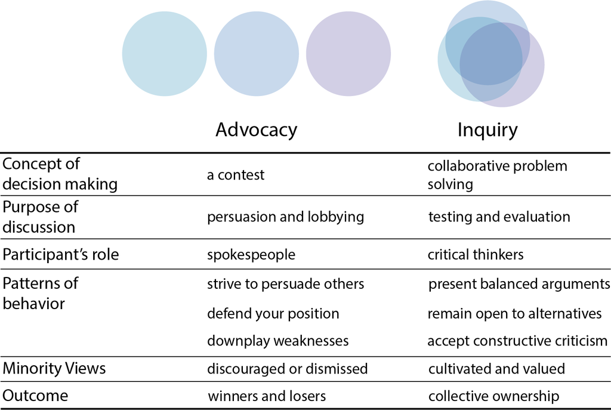

Contrasting decision approaches in team efforts

In the innovation process detailed in this book, I have never seen a team succeed that was also highly engaged in advocacy. If you want to succeed with high probability, embrace inquiry. Instead, prioritize your team members, your customers, and the team’s innovation over yourself. If you do, you will be more likely to succeed personally and do it while enjoying the emotional benefits of helping others succeed.

### 2.2.1 Advocacy: Competition to Win within the Team

In an advocacy-driven team, members focus on asserting their ideas and achieving personal dominance. This competitive mindset fosters an environment where members are more concerned with winning arguments than finding the best solutions. It often leads to a situation where the loudest, most persuasive, or most dominant voices prevail, rather than the best ideas.

### 2.2.2 Inquiry: Collaboration to Win for the Customer

In contrast, inquiry-based teams prioritize a more open and cooperative approach. Here, the objective is to explore multiple alternatives, exchange ideas freely, and collectively work towards well-considered solutions. This approach is characterized by a focus on mutual problem-solving rather than individual victories.

### 2.2.3 Conflict in Advocacy vs. Inquiry

Note that conflict is present in both approaches. However, the nature of conflict in inquiry is constructive, aimed at evaluating and improving ideas. In advocacy, conflict often degenerates into personal attacks and self-aggrandizement, sidelining the process of idea generation and selection.

The tendency towards advocacy can be a major pitfall for teams, leading to suboptimal outcomes and strained dynamics. Recognizing the signs of an advocacy-dominated environment is crucial, as is knowing strategies to steer the team towards more productive, inquiry-based collaboration.

## 2.3 Advocating Psychological Safety in Team Dynamics

While interdisciplinary teams have the potential to harness diverse skills for innovative solutions, this diversity can also be a source of conflict if not managed correctly. One of the most critical aspects of managing this diversity effectively is by ensuring psychological safety within the team.[^4]

Protecting the psychological safety of team members is not just about ensuring comfort; it’s about creating an environment where every member can contribute their best ideas without fear. This section delves into the practices and measures that can build and maintain psychological safety within a team.

### 2.3.1 The Concept of Psychological Safety

Google studied the keys to success in over 200 teams and published the startling result that the key to effective teams lies not in the individual capabilities of team members but in how they interact, structure their work, and view their contributions.[^5] Central to this is the concept of *psychological safety*, defined as a shared belief among team members that the team is safe for interpersonal risk-taking. This environment allows team members to present ideas and questions without fear of negative consequences, fostering a culture of open collaboration and collective problem-solving.

### 2.3.2 Building Psychological Safety: Practical Steps

Building psychological safety is a deliberate process, requiring conscious effort to create an environment that encourages open and honest communication. Some effective practices include:

- **Demonstrating Engagement:** Actively participate in discussions, showing genuine interest in teammates’ ideas, and listening attentively.
- **Showing Understanding:** Validate others’ contributions, focusing on understanding rather than blaming.
- **Inclusivity in Interpersonal Settings:** Share your preferences, express gratitude, and defend team members against undue criticism.
- **Inclusivity in Decision-Making:** Actively seek and acknowledge everyone’s input in team decisions.
- **Balancing Confidence and Flexibility:** Exhibit confidence in your ideas while remaining open to others’ perspectives and avoiding rigidity.

### 2.3.3 Assessing Psychological Safety

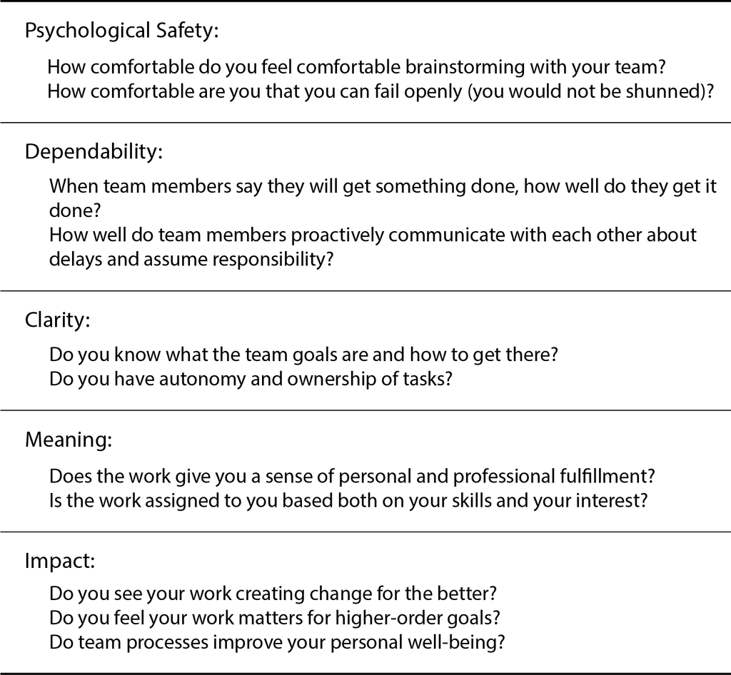

By focusing on these aspects, teams can move beyond just coexistence to truly collaborative and innovative problem-solving. Psychological safety is the bedrock upon which successful interdisciplinary teams are built. It enables team members to leverage their diverse skills fully, leading to more innovative and effective solutions. The commitment to nurturing an environment of psychological safety, can transform the potential of an interdisciplinary team into a reality of creative and impactful innovation. This approach ensures that team members not only contribute their best but also feel valued and supported in the process.

Creating a culture of cooperation and collaboration in an interdisciplinary team requires a conscious effort and commitment from all team members. Successful teams typically exhibit a common purpose, specific performance goals, diverse skills, a clear commitment to work processes, and mutual accountability. One effective way to achieve these objectives is through developing a team charter.

## 2.4 Team Charter

A practical tool for nurturing psychological safety is the creation and utilization of a *team charter*. A team charter is a contract among team members, establishing the team’s purpose, roles, rules, and procedures, thereby guiding its collaborative efforts. It can outline agreed-upon norms and practices that promote psychological safety, ensuring every team member knows what to expect and what is expected of them.

A team charter is not just a formality; it’s a crucial tool for fostering a collaborative culture. It lays the groundwork for teamwork and innovation by clarifying team objectives and processes. The charter may evolve over time, adapting to the team’s changing purpose and methods.

### 2.4.1 Elements of a Team Charter

The team charter should cover several key areas to ensure effective team functioning. While the specific contents will vary based on the team’s needs, some core elements are generally useful:

#### 1. Project Objective Statement

A clear and concise statement of the team’s project and goals, providing direction and unity. It should outline the project’s scope, schedule, and resources. A well-defined objective statement serves as a mission, guiding the team amidst complex details. It should describe *what* will be done (scope of the project), *when* it will be done (schedule of the project), and *how much* it will cost (resources needed for the project). The resources for the project should include the expertise of the team members, tools, and budget required to accomplish the scope of the project on schedule.

Here is an example of a project objective statement for a project developing a human-powered drill for digging water wells:[^6]

> Design, build, and test a human-powered drill that reaches underground potable water at depths of 250 ft in all soil types by March 25, 2011 with a prototyping budget of $2,800 USD for less than 1,700 hours of development.

#### 2. Ownership Structure

Define the equity distribution among team members, considering contributions and future expectations. This section should address how to handle departures, ownership transfer, and equity compensation. It’s crucial to establish these rules upfront to prevent conflicts as the project progresses.

People who contribute something must be compensated. Determine who gets equity based on forward looking considerations – incentives for future contributions that can be issued based on milestones such as outside investment, vesting, time, or progress in the company. Assign ownership of the team (company) according to an agreed upon rule. There are three common approaches to allocating founder equity but only one creates incentive that encourage participation with less risk of fights over fairness:

- Allocate equity immediately so there is nothing to fight about.
- Wait to allocate equity until you understand the value of founder contributions.
- Allocate a few shares to every member immediately and then allocate future shares based on contributions and value creation.

In the early days of a team, you typically do not know who will eventually contribute the most value. To avoid unfair allocations, award a small number of shares for participation in the team and regularly allocate more shares for continued participation. For example, you may want to allocate one share to each member for every month of participation in the team. This way every team member is compensated for their work but there are few enough shares allocated that it does not create conflict when value creation becomes clearer and equity allocation is not equal.

You should also choose a method for owners to leave the team. For example, if a team member decides to leave, they will be compensated for their accumulated equity at the current value of the company. Similarly, if a member of the team dies, you can specify that their ownership passes to another party only after approval by the other team members. These are just examples. Discuss these issues and choose a method that you agree on. Once you agree, live by the agreement. You can change the allocation rules later if the change is agreed to.

#### 3. Roles and Responsibilities

Clearly defined roles and responsibilities for each team member enhance clarity and accountability. The charter should also be flexible enough to adapt to new tasks and changing team dynamics. You should revisit the roles and responsibilities as you learn more about the work to be done and the skills and preferences of the team members. When a new task needs to be done, assign it as a responsibility to a team member with the approval of the team.

#### 4. Decision-Making Process

You should also specify what decisions a team member can make while fulfilling their tasks and what decisions need to be brought back to the team for consideration.

#### 5. Ground Rules

Lay out specific protocols for communication, participation, work products, conflict management, and attendance. These guidelines will help maintain order and ensure productive team interactions.

- **Communication:** How will you communicate with each other? How often? With whom? Will you use e-mail, telephones, text, or a social platform? Is there a time of day or night that is off-limits for calling a team member? Do some team members respond better and faster to e-mail than phone mail? You should consider the following questions in developing a team communication protocol.
- **Participation:** We expect all members to participate equally and actively in all team activities and work.
- **Work Products:** All members will contribute their share of the work, delivering end products complete and on time. The team will use project management processes to assign tasks and require accountability.
- **Conflict Management:** We encourage healthy debate about content within the meetings; however, the facilitator will directly address conflict that disrupts the team. Anyone who feels a conflict exists that is not being addressed has the responsibility to bring it to the facilitator or team for resolution.
- **Preparation:** All members must be aware of agenda items for the day and have their portions of the work completed before the meeting starts.
- **Attendance:** We require attendance at all team meetings. If an unexpected conflict arises, the member is responsible for sending in his or her work for the day and for notifying the team.

#### 6. Addressing Violations

Develop a tiered response to rule violations, balancing accountability with constructive outcomes. This approach helps maintain discipline while being fair and proportionate to the nature of the violation.

### 2.4.2 Guidelines for Developing the Team Charter

- The charter should be a collaborative effort, reflecting the input of all team members.
- Avoid delegating the charter creation to a single individual; use inclusive methods like whiteboard sessions or notecard pooling.
- All members should sign the charter to formalize their commitment.
- Schedule regular reviews of the charter to adapt to the team’s evolving needs.
- Display the charter prominently to reinforce its importance and remind team members of their commitments.

### 2.4.3 Managing Tasks and Accountability

Apply project management principles to assign tasks and manage accountability effectively. This structured approach ensures that the team’s efforts in navigating the uncertainties of innovation lead to success.

## 2.5 Organizing to Harness the Power of Team Collaboration

Innovation thrives in an environment fostered by effective teamwork. The journey of creating and sustaining a successful interdisciplinary team is complex, yet achievable through deliberate and strategic efforts. As we’ve explored in this chapter, the key to unlocking the full potential of a team lies in understanding the stages of team development, advocating inquiry over advocacy, safeguarding psychological safety, and establishing a robust team charter.

The stages of team development — forming, storming, norming, and performing — provide a roadmap for teams to navigate the complexities of collaboration. Embracing these stages with awareness and adaptability enables teams to evolve from a group of individuals with diverse skills to a cohesive unit with a shared vision.

Advocacy versus inquiry is a critical distinction that can make or break the creative problem-solving process. Teams should strive for an environment where ideas are shared freely and evaluated on their merit, not based on who proposed them. This shift from self-promotion to collective problem-solving is pivotal for fostering innovation.

Psychological safety stands as the cornerstone of effective team collaboration. A team environment where members feel safe to take risks, share ideas, and express concerns without fear of reprisal is essential for creativity and innovation. Regularly assessing and reinforcing psychological safety ensures that all team members can contribute their best.

Finally, the development of a team charter is a practical tool for aligning team members towards common goals and establishing clear roles, responsibilities, and protocols. A well-crafted charter not only provides clarity and structure but also serves as a living document that evolves with the team’s needs.

In conclusion, the successful management of interdisciplinary teams in the entrepreneurial landscape requires a balanced approach that respects individual contributions while prioritizing collective goals. By fostering a culture of inquiry, psychological safety, and structured collaboration, teams can navigate the challenges of innovation and harness their collective potential to create impactful solutions.

Duhigg, Charles. 2016. “What Google Learned from Its Quest to Build the Perfect Team.” February 25, 2016. https://www.nytimes.com/2016/02/28/magazine/what-google-learned-from-its-quest-to-build-the-perfect-team.html?smid=pl-share&_r=0.

Edmondson, Amy. 1999. “Psychological Safety and Learning Behavior in Work Teams.” *Administrative Science Quarterly* 44 (2): 350–83.

Gardner, Richard G., Jeffrey S. Bednar, Bryan W. Stewart, James B. Oldroyd, and Joseph Moore. 2019. “I Must Have Slipped Through the Cracks Somehow?: An Examination of Coping with Perceived Impostorism and the Role of Social Support.” *Journal of Vocational Behavior* 115: 103337.

Garvin, David A., and Michael A. Roberto. 2001. “What You Don’t Know about Making Decisions.” *Harvard Business Review* 79 (8): 108–19.

Mattson, Christopher A., and Carl D. Sorensen. 2018. *Fundamentals of Product Development*. 5th ed.

Tamiru, Natasha. 2023. “Team Dynamics: Five Keys to Building Effective Teams.” June 1, 2023. https://www.thinkwithgoogle.com/intl/en-emea/consumer-insights/consumer-trends/five-dynamics-effective-team/.

Tuckman, Bruce W. 1965. “Developmental Sequence in Small Groups.” *Psychological Bulletin* 63 (6): 384.

[^1]: For more detail on the stages of team development, see the work of Bruce Tuckman (1965).
[^2]: Even qualified team members can sometimes suffer from the imposter syndrome that can make them cautious about sharing their skills and insights for fear of being exposed as a fraud. (Gardner et al. (2019)).
[^3]: For more detail on making decisions with inquiry rather than advocacy, see Garvin and Roberto (2001).
[^4]: There is a stream of research on psychological safety that began with the pioneering work of Amy Edmondson (1999).
[^5]: For more detail on this insightful study by Julia Rozovsky, see the articles by Charles Duhigg (2016) and Natasha Tamiru (2023).
[^6]: This example is drawn from Mattson and Sorensen (2018).

This book was written by Nile Hatch (2024)